**City College of San Francisco**

MATH 108 - Foundations of Data Science

# Lecture 16: Assessing Models

Associated Textbook Sections: [10.4, 11.0, 11.1](https://inferentialthinking.com/chapters/10/4/Random_Sampling_in_Python.html)

## Set Up the Notebook

```python
from datascience import *
import numpy as np
%matplotlib inline
import matplotlib.pyplot as plots
plots.style.use('fivethirtyeight')
```

# Table of Contents

## Assessing Models

### Models

- A model is a set of assumptions about the data
- In data science, many models involve assumptions about processes that involve randomness ("Chance models")
- Key question: Does the model fit the data?

### Approach to Assessment

- If we can simulate data according to the assumptions of the model, we can learn what the model predicts.
- We can then compare the predictions to the data that were observed.
- If the data and the model's predictions are not consistent, that is evidence against the model.

## Jury Selection

### Swain vs. Alabama, 1965

- Talladega County, Alabama
- Robert Swain, Black man convicted of crime
- Appeal: one factor was all-White jury
- Only men 21 years or older were allowed to serve
- 26% of this population were Black
- Swain's jury panel consisted of 100 men
- 8 men on the panel were Black

### Supreme Court Ruling (In English ... of the time)

- About disparities between the percentages in the eligible population and the jury panel, the Supreme Court wrote:

  > "... the overall percentage disparity has been small and reflects no studied attempt to include or exclude a specified number of Negroes"
- The Supreme Court denied Robert Swain’s appeal

### Supreme Court Ruling (in Data)

- Paraphrase: 8/100 is less than 26%, but not different enough to show Black men were systematically excluded
- Question: is 8/100 a realistic outcome if the jury panel selection process were truly unbiased?

### Sampling from a Distribution

- Sample at random from a categorical distribution using `sample_proportions(sample_size, pop_distribution)`
- Samples at random from the population returns an array containing the distribution of the categories in the sample

### Demo: Swain vs. Alabama

Create an 2-valued array that reflects the proportion of the population that is Black and not Black.

```python
pop_proportions = make_array(0.26, 0.74) # Part of the model about how the data was made
pop_proportions
```

```
array([0.26, 0.74])
```

Use `sample_proportions` to create the proportions of a sample of size 100 from the population defined by the above array values.

```python
sample_proportions(100, pop_proportions)
```

```
array([0.36, 0.64])
```

```python
def panel_proportion():
    return sample_proportions(100, pop_proportions).item(0)
```

```python
panel_proportion()
```

```
0.26
```

```python
panels = make_array()

for _ in np.arange(10000):
    new_panel = panel_proportion() * 100
    panels = np.append(panels, new_panel)
```

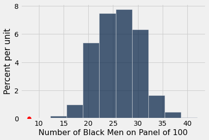

```python
Table().with_column('Number of Black Men on Panel of 100', panels).hist()
plots.scatter(8, 0, color="red", s=60, zorder=3);
```

## A Genetic Model

### Gregor Mendel, 1822-1884

[figure not shown]

Image Source: [Wikipedia - Gregor Mendel](https://en.wikipedia.org/wiki/Gregor_Mendel)

### A Model

- Pea plants of a particular kind
- Each one has either purple flowers or white flowers
- Mendel’s model: Each plant is purple-flowering with chance 75%, regardless of the colors of the other plants
- Question: Is the model good, or not?

### Choosing a Statistic

- Take a sample, see what percent are purple-flowering
- If that percent is much larger or much smaller than 75, that is evidence against the model
- Distance from 75 is the key
- Statistic: `abs(sample_percent_of_purple_flowering_plants - 75)`
- If the statistic is large, that is evidence against the model

### Demo: Mendel and Pea Flowers

Define the observed proportion of purple flowers in Mendel's data and the predicted population proportions for purple and non-purple flowers.

```python
# Based on Mendel's actual plant
observed_purples = 709/929
observed_purples
```

```
0.7631862217438106
```

Simulate sampling 929 plants from a population with the proportions predicted by Mendel.

```python
predicted_proportions = make_array(0.75, 0.25) # Model:75% purple
predicted_proportions
```

```
array([0.75, 0.25])
```

Simulate randomly selecting samples of 929 plants based on Mendel's model. Repeat this process 10000 times and visualize the distribution of the sample proportions.

```python
sample_proportions(929, predicted_proportions)
```

```
array([0.74919268, 0.25080732])
```

```python
def purple_flowers():
    return sample_proportions(929, predicted_proportions).item(0) * 100
```

```python
purple_flowers()
```

```
74.91926803013995
```

```python
purples = make_array()

for _ in np.arange(10000):
    new_purple = purple_flowers()
    purples = np.append(purples, new_purple)
```

```python
purples
```

```
array([74.05812702, 77.07212056, 75.45748116, ..., 74.05812702,
       73.19698601, 74.16576964])
```

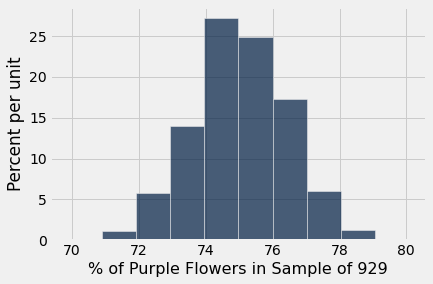

```python
Table().with_column('% of Purple Flowers in Sample of 929', purples).hist()
```

Visualize the distribution of the test statistics created from the simulations and identify where the observed statistic fits in the distribution.

```python
test_statistics = Table().with_column('Discrepancy in sample of 929', abs(purples - 75))
test_statistics
```

| Discrepancy in sample of 929 |
| --- |
| 0.941873 |
| 2.07212 |
| 0.457481 |
| 0.134553 |
| 1.31862 |
| 0.188375 |
| 2.34123 |
| 1.96448 |
| 0.565124 |
| 1.37244 |

... (9990 rows omitted)

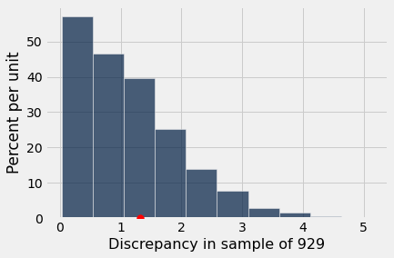

```python
observed_test_stat = abs(observed_purples*100 - 75)
test_statistics.hist()
plots.scatter(observed_test_stat, 0, color="red", s=60, zorder=3);
```

## Two Viewpoints

### Model and Alternative

- Jury selection:
  - Model: The people on the jury panels were selected at random from the eligible population
  - Alternative viewpoint: No, they weren't
- Genetics:
  - Model: Each plant has a 75% chance of having purple flowers
  - Alternative viewpoint: No, it doesn't

### Steps in Assessing a Model

- Choose a statistic to measure discrepancy between model and data
- Simulate the statistic under the model’s assumptions
- Compare the data to the model’s predictions:
  - Draw a histogram of simulated values of the statistic
  - Compute the observed statistic from the real sample
  - If the observed statistic is far from the histogram, that is evidence against the model